# Exploratory Analysis

```python
import pandas as pd
import numpy as np
import matplotlib.pyplot as plt
import seaborn as sns

# Set plot style
pd.set_option('display.max_columns', None)

FILE_PATH = 'cse158-assignment2-master.csv'
SAMPLE_SIZE = 1_000_000

df = pd.read_csv(
    FILE_PATH,
    nrows=SAMPLE_SIZE,
    low_memory=True,
    dtype={
        "loser.trophies": pd.Int16Dtype(),
        "winner.trophies": pd.Int16Dtype(),
        "winner.troops": pd.Int16Dtype(),
        "winner.structures": pd.Int16Dtype(),
        "winner.spells": pd.Int16Dtype(),
        "loser.troops": pd.Int16Dtype(),
        "loser.structures": pd.Int16Dtype(),
        "loser.spells": pd.Int16Dtype(),
    },
)
df.drop("Unnamed: 0", axis=1, inplace=True)
```

```python
print("Dataset Shape:", df.shape)
print("\nColumn Names:", df.columns.tolist())
print("\nFirst 5 rows:")
display(df.head())
```

```
Dataset Shape: (1000000, 22)

Column Names: ['winner.trophies', 'winner.isinclan', 'loser.trophies', 'loser.isinclan', 'winner.cards', 'winner.troops', 'winner.structures', 'winner.spells', 'winner.commons', 'winner.rares', 'winner.epics', 'winner.legendaries', 'winner.elixir.average', 'loser.cards', 'loser.troops', 'loser.struc…

First 5 rows:
```

|  | winner.trophies | winner.isinclan | loser.trophies | loser.isinclan | winner.cards | winner.troops | winner.structures | winner.spells | winner.commons | winner.rares | winner.epics | winner.legendaries | winner.elixir.average | loser.cards | loser.troops | loser.structures | loser.spells | loser.commons | loser.rares | loser.epics | loser.legendaries | loser.elixir.average |
| --- | --- | --- | --- | --- | --- | --- | --- | --- | --- | --- | --- | --- | --- | --- | --- | --- | --- | --- | --- | --- | --- | --- |
| 0 | 5372 | True | 5354 | True | [26000003, 26000004, 26000006, 26000008, 26000... | 5 | 1 | 2 | 3 | 2 | 3 | 0 | 4.500 | [26000000, 26000015, 26000023, 27000004, 28000... | 3 | 1 | 4 | 1 | 1 | 4 | 2 | 3.500 |
| 1 | 5409 | False | 5405 | True | [26000000, 26000010, 26000026, 26000040, 26000... | 5 | 1 | 2 | 2 | 2 | 2 | 2 | 2.875 | [26000023, 26000027, 26000037, 26000046, 26000... | 6 | 1 | 1 | 0 | 1 | 2 | 5 | 4.250 |
| 2 | 5749 | True | 5733 | True | [26000010, 26000042, 26000044, 26000055, 26000... | 6 | 0 | 2 | 2 | 1 | 2 | 3 | 3.500 | [26000022, 26000027, 26000028, 26000041, 26000... | 7 | 0 | 1 | 4 | 2 | 1 | 1 | 4.125 |
| 3 | 4316 | True | 4298 | True | [26000016, 26000023, 26000026, 26000041, 28000... | 4 | 0 | 4 | 1 | 1 | 3 | 3 | 3.250 | [26000012, 26000027, 26000031, 26000033, 26000... | 6 | 1 | 1 | 2 | 1 | 2 | 3 | 3.750 |
| 4 | 5783 | True | 5770 | True | [26000010, 26000014, 26000021, 26000030, 26000... | 5 | 1 | 2 | 3 | 4 | 0 | 1 | 2.625 | [26000010, 26000011, 26000021, 26000037, 26000... | 5 | 1 | 2 | 2 | 4 | 0 | 2 | 3.250 |

```python
df.describe()
```

|  | winner.trophies | loser.trophies | winner.troops | winner.structures | winner.spells | winner.commons | winner.rares | winner.epics | winner.legendaries | winner.elixir.average | loser.troops | loser.structures | loser.spells | loser.commons | loser.rares | loser.epics | loser.legendaries | loser.elixir.average |
| --- | --- | --- | --- | --- | --- | --- | --- | --- | --- | --- | --- | --- | --- | --- | --- | --- | --- | --- |
| count | 1000000.0 | 1000000.0 | 1000000.0 | 1000000.0 | 1000000.0 | 1000000.000000 | 1000000.000000 | 1000000.000000 | 1000000.000000 | 1000000.000000 | 1000000.0 | 1000000.0 | 1000000.0 | 1000000.000000 | 1000000.000000 | 1000000.000000 | 1000000.000000 | 1000000.000000 |
| mean | 4732.462993 | 4731.791999 | 5.616992 | 0.434842 | 1.948166 | 2.037757 | 1.991118 | 2.275796 | 1.695329 | 3.835736 | 5.612921 | 0.449681 | 1.937398 | 2.052727 | 2.023654 | 2.244362 | 1.679257 | 3.831667 |
| std | 778.502191 | 778.539755 | 1.09377 | 0.586106 | 0.86723 | 1.310777 | 1.266420 | 1.406816 | 1.251777 | 0.520909 | 1.112468 | 0.617589 | 0.898244 | 1.322980 | 1.281949 | 1.411338 | 1.271941 | 0.532007 |
| min | 25.0 | 25.0 | 0.0 | 0.0 | 0.0 | 0.000000 | 0.000000 | 0.000000 | 0.000000 | 1.500000 | 0.0 | 0.0 | 0.0 | 0.000000 | 0.000000 | 0.000000 | 0.000000 | 1.500000 |
| 25% | 4366.0 | 4365.0 | 5.0 | 0.0 | 1.0 | 1.000000 | 1.000000 | 1.000000 | 1.000000 | 3.500000 | 5.0 | 0.0 | 1.0 | 1.000000 | 1.000000 | 1.000000 | 1.000000 | 3.500000 |
| 50% | 4722.0 | 4721.0 | 6.0 | 0.0 | 2.0 | 2.000000 | 2.000000 | 2.000000 | 2.000000 | 3.875000 | 6.0 | 0.0 | 2.0 | 2.000000 | 2.000000 | 2.000000 | 2.000000 | 3.875000 |
| 75% | 5148.0 | 5147.0 | 6.0 | 1.0 | 2.0 | 3.000000 | 3.000000 | 3.000000 | 2.000000 | 4.125000 | 6.0 | 1.0 | 2.0 | 3.000000 | 3.000000 | 3.000000 | 2.000000 | 4.125000 |
| max | 7378.0 | 7411.0 | 8.0 | 8.0 | 8.0 | 8.000000 | 8.000000 | 8.000000 | 8.000000 | 7.375000 | 8.0 | 8.0 | 8.0 | 8.000000 | 8.000000 | 8.000000 | 8.000000 | 7.696429 |

## Check missing values

```python
missing_values = df.isnull().sum()
missing_values = missing_values[missing_values > 0]

if not missing_values.empty:
    print("Columns with missing values:")
    print(missing_values)
else:
    print("No missing values found in the sample.")
```

```
No missing values found in the sample.
```

## Feature Distribution Analysis

### Frequency distributions

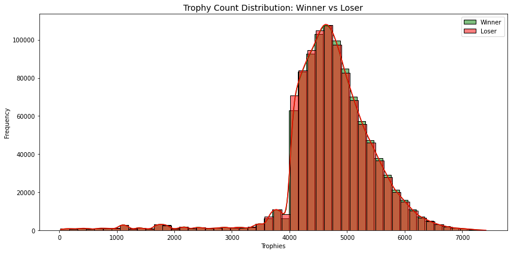

```
Winner Trophies - Mean: 4732, Median: 4722
Loser Trophies  - Mean: 4732, Median: 4721
```

```python
fig, ax = plt.subplots(figsize=(12, 6))

sns.histplot(df['winner.trophies'], bins=50, kde=True, color='green', alpha=0.5, label='Winner', ax=ax)
sns.histplot(df['loser.trophies'], bins=50, kde=True, color='red', alpha=0.5, label='Loser', ax=ax)

ax.set_title('Trophy Count Distribution: Winner vs Loser', fontsize=14)
ax.set_xlabel('Trophies')
ax.set_ylabel('Frequency')
ax.legend()
plt.tight_layout()
plt.show()

print(f"Winner Trophies - Mean: {df['winner.trophies'].mean():.0f}, Median: {df['winner.trophies'].median():.0f}")
print(f"Loser Trophies  - Mean: {df['loser.trophies'].mean():.0f}, Median: {df['loser.trophies'].median():.0f}")
```

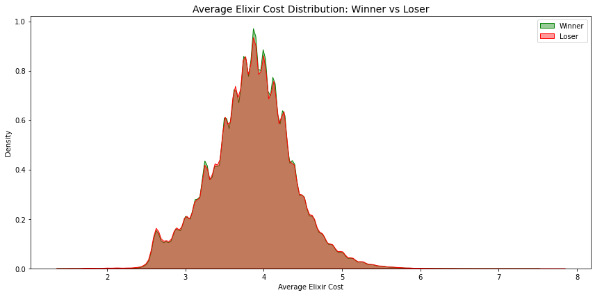

```
Winner Elixir - Mean: 3.84, Median: 3.88
Loser Elixir  - Mean: 3.83, Median: 3.88
Prop. of winners with heavier decks: 46.70%
```

```python
# Average Elixir Distribution: Winner vs Loser
plt.figure(figsize=(12, 6))

# Use more bins and adjust KDE bandwidth for smoother curves
sns.kdeplot(df['winner.elixir.average'], color='green', alpha=0.4, label='Winner', fill=True, bw_adjust=1.5)
sns.kdeplot(df['loser.elixir.average'], color='red', alpha=0.4, label='Loser', fill=True, bw_adjust=1.5)

plt.title('Average Elixir Cost Distribution: Winner vs Loser', fontsize=14)
plt.xlabel('Average Elixir Cost')
plt.ylabel('Density')
plt.legend()
plt.tight_layout()
plt.show()

print(f"Winner Elixir - Mean: {df['winner.elixir.average'].mean():.2f}, Median: {df['winner.elixir.average'].median():.2f}")
print(f"Loser Elixir  - Mean: {df['loser.elixir.average'].mean():.2f}, Median: {df['loser.elixir.average'].median():.2f}")

print(f"Prop. of winners with heavier decks: {(df['winner.elixir.average'] - df['loser.elixir.average'] > 0).mean():.2%}")
```

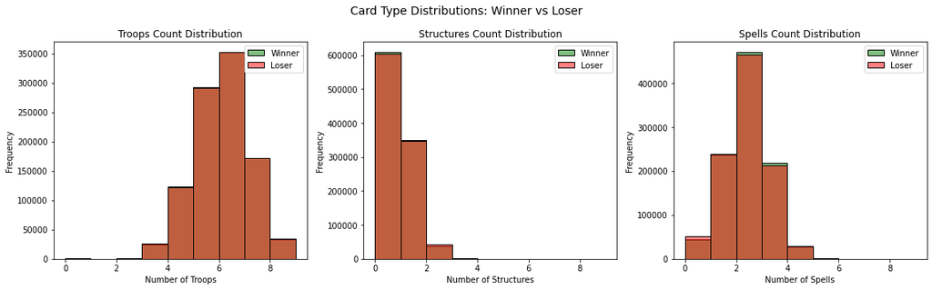

```
Card Type Summary Statistics:

Troops:
  Winner - Mean: 5.62
  Loser  - Mean: 5.61

Structures:
  Winner - Mean: 0.43
  Loser  - Mean: 0.45

Spells:
  Winner - Mean: 1.95
  Loser  - Mean: 1.94
```

```python
card_types = ['troops', 'structures', 'spells']
fig, axes = plt.subplots(1, 3, figsize=(16, 5))

for i, ctype in enumerate(card_types):
    ax = axes[i]
    sns.histplot(df[f'winner.{ctype}'], bins=range(0, 10), kde=False, color='green', alpha=0.5, label='Winner', ax=ax)
    sns.histplot(df[f'loser.{ctype}'], bins=range(0, 10), kde=False, color='red', alpha=0.5, label='Loser', ax=ax)
    ax.set_title(f'{ctype.capitalize()} Count Distribution', fontsize=12)
    ax.set_xlabel(f'Number of {ctype.capitalize()}')
    ax.set_ylabel('Frequency')
    ax.legend()

plt.suptitle('Card Type Distributions: Winner vs Loser', fontsize=14)
plt.tight_layout()
plt.show()

# Print summary statistics
print("Card Type Summary Statistics:")
for ctype in card_types:
    print(f"\n{ctype.capitalize()}:")
    print(f"  Winner - Mean: {df[f'winner.{ctype}'].mean():.2f}")
    print(f"  Loser  - Mean: {df[f'loser.{ctype}'].mean():.2f}")
```

**Observations:**

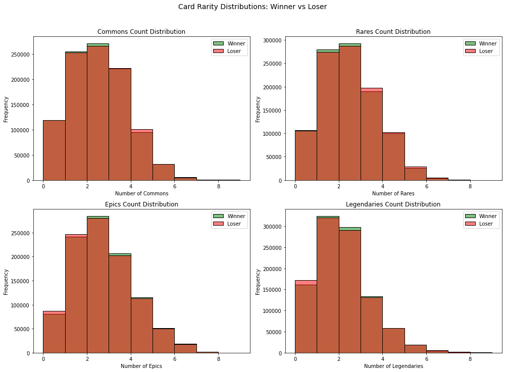

```python
rarities = ['commons', 'rares', 'epics', 'legendaries']
fig, axes = plt.subplots(2, 2, figsize=(14, 10))
axes = axes.flatten()

for i, rarity in enumerate(rarities):
    ax = axes[i]
    sns.histplot(df[f'winner.{rarity}'], bins=range(0, 10), kde=False, color='green', alpha=0.5, label='Winner', ax=ax)
    sns.histplot(df[f'loser.{rarity}'], bins=range(0, 10), kde=False, color='red', alpha=0.5, label='Loser', ax=ax)
    ax.set_title(f'{rarity.capitalize()} Count Distribution', fontsize=12)
    ax.set_xlabel(f'Number of {rarity.capitalize()}')
    ax.set_ylabel('Frequency')
    ax.legend()

plt.suptitle('Card Rarity Distributions: Winner vs Loser', fontsize=14, y=1.02)
plt.tight_layout()
plt.show()
```

## Trophy Distribution Analysis

Instead of just looking at the raw distribution of trophies (which is symmetric due to matchmaking), we will analyze the **difference** in trophies between the winner and the loser. This reveals if having a slightly higher trophy count (within the matchmaking range) is a predictor of winning.

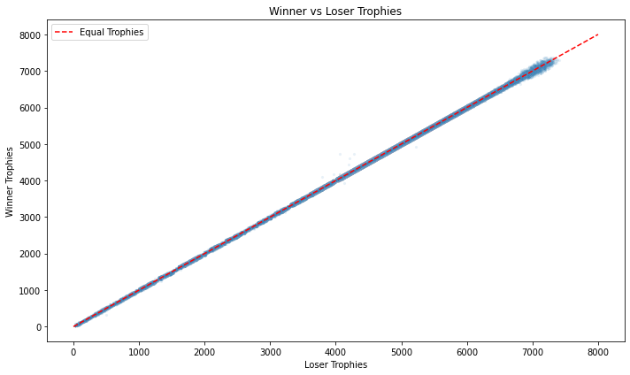

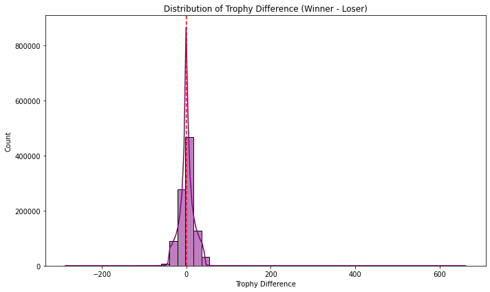

```
Percentage of matches where Winner has more trophies: 48.48%
```

```python
# Calculate difference
df['trophy_diff'] = df['winner.trophies'] - df['loser.trophies']

# Scatter Plot
plt.figure(figsize=(10, 6))
sns.scatterplot(data=df, x='loser.trophies', y='winner.trophies', alpha=0.1, s=10)
plt.plot([0, 8000], [0, 8000], 'r--', label='Equal Trophies')  # Diagonal line
plt.title('Winner vs Loser Trophies')
plt.xlabel('Loser Trophies')
plt.ylabel('Winner Trophies')
plt.legend()
plt.tight_layout()
plt.show()

# Difference Histogram
plt.figure(figsize=(10, 6))
sns.histplot(data=df, x='trophy_diff', bins=50, kde=True, color='purple')
plt.axvline(0, color='red', linestyle='--')
plt.title('Distribution of Trophy Difference (Winner - Loser)')
plt.xlabel('Trophy Difference')
plt.tight_layout()
plt.show()

print(f"Percentage of matches where Winner has more trophies: {(df['trophy_diff'] > 0).mean():.2%}")
```

**Observations:**

The distributions of trophies for winners and losers are likely to be very similar due to the matchmaking system which pairs players of similar skill levels. But there is a slightly higher variation in trophies the higher up you get.

## Clan Membership Analysis

We analyze whether being in a clan provides a winning advantage. We will look at a cross-tabulation of matches to see who wins when a player is in a clan.

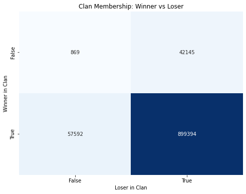

```
Matches where only one player is in a clan: 99737
Winner was the one in clan: 57592 (57.74%)
Loser was the one in clan: 42145 (42.26%)
```

```python
clan_crosstab = pd.crosstab(df['winner.isinclan'], df['loser.isinclan'])
clan_crosstab.index.name = "Winner in Clan"
clan_crosstab.columns.name = "Loser in Clan"

plt.figure(figsize=(8, 6))
sns.heatmap(clan_crosstab, annot=True, fmt='d', cmap='Blues', cbar=False)
plt.title('Clan Membership: Winner vs Loser')
plt.show()

# Analyze the "Mixed" cases
winner_in_loser_out = clan_crosstab.loc[True, False]
winner_out_loser_in = clan_crosstab.loc[False, True]
total_mixed = winner_in_loser_out + winner_out_loser_in

print(f"Matches where only one player is in a clan: {total_mixed}")
print(f"Winner was the one in clan: {winner_in_loser_out} ({winner_in_loser_out/total_mixed:.2%})")
print(f"Loser was the one in clan: {winner_out_loser_in} ({winner_out_loser_in/total_mixed:.2%})")
```

**Observations:**

## Card Rarity Distribution

Does having more Epics or Legendaries than your opponent increase your chances of winning? We analyze the count differences.

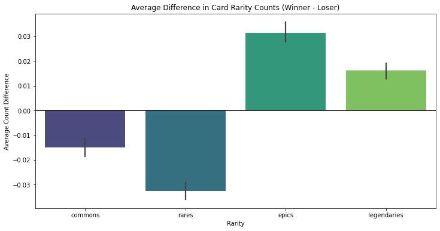

```
Interpretation: Positive bars indicate the winner typically has MORE of that rarity than the loser.
```

```python
rarities = ['commons', 'rares', 'epics', 'legendaries']

# Calculate differences
for rarity in rarities:
    df[f'{rarity}_diff'] = df[f'winner.{rarity}'] - df[f'loser.{rarity}']

# Melt for plotting
rarity_diff_data = pd.melt(df[[f'{r}_diff' for r in rarities]], var_name='Rarity', value_name='Difference')
rarity_diff_data['Rarity'] = rarity_diff_data['Rarity'].str.replace('_diff', '')

plt.figure(figsize=(12, 6))
sns.barplot(x='Rarity', y='Difference', data=rarity_diff_data, palette='viridis', errorbar=('ci', 95))
plt.axhline(0, color='black', linestyle='-')
plt.title('Average Difference in Card Rarity Counts (Winner - Loser)')
plt.ylabel('Average Count Difference')
plt.show()

print("Interpretation: Positive bars indicate the winner typically has MORE of that rarity than the loser.")
```

**Observations:**

## Feature Differences and "Advantage"

To better understand what drives a win, we calculate the difference between the winner's and loser's features for each match. This represents the "advantage" the winner had.

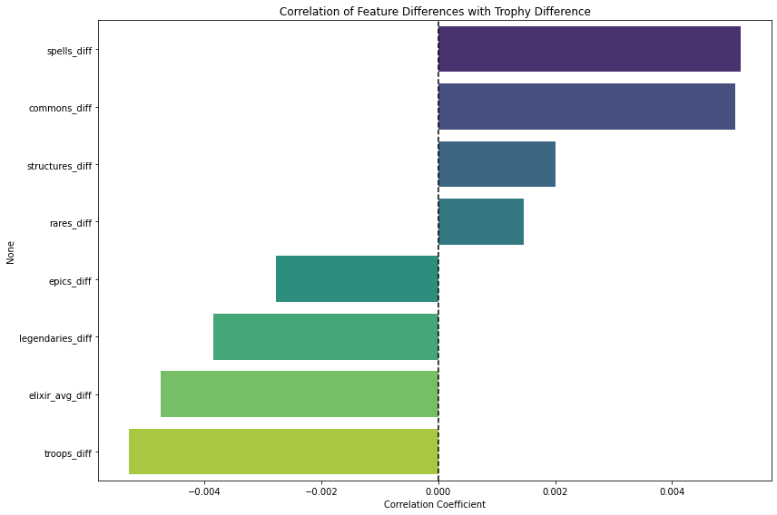

```
Correlations with Trophy Difference:
spells_diff         0.005172
commons_diff        0.005077
structures_diff     0.002012
rares_diff          0.001459
epics_diff         -0.002773
legendaries_diff   -0.003850
elixir_avg_diff    -0.004743
troops_diff        -0.005286
Name: trophies_diff, dtype: float64
```

```python
# Create difference columns
feature_pairs = [
    ('trophies', 'winner.trophies', 'loser.trophies'),
    ('troops', 'winner.troops', 'loser.troops'),
    ('structures', 'winner.structures', 'loser.structures'),
    ('spells', 'winner.spells', 'loser.spells'),
    ('commons', 'winner.commons', 'loser.commons'),
    ('rares', 'winner.rares', 'loser.rares'),
    ('epics', 'winner.epics', 'loser.epics'),
    ('legendaries', 'winner.legendaries', 'loser.legendaries'),
    ('elixir_avg', 'winner.elixir.average', 'loser.elixir.average')
]

diff_cols = []
for name, win_col, lose_col in feature_pairs:
    if win_col in df.columns and lose_col in df.columns:
        col_name = f'{name}_diff'
        df[col_name] = df[win_col] - df[lose_col]
        diff_cols.append(col_name)

# Correlation with Trophy Difference
if 'trophies_diff' in df.columns:
    trophy_corrs = df[diff_cols].corr()['trophies_diff'].drop('trophies_diff').sort_values(ascending=False)

    plt.figure(figsize=(12, 8))
    sns.barplot(x=trophy_corrs.values, y=trophy_corrs.index, palette='viridis')
    plt.title('Correlation of Feature Differences with Trophy Difference')
    plt.xlabel('Correlation Coefficient')
    plt.axvline(0, color='black', linestyle='--')
    plt.tight_layout()
    plt.show()

    print("Correlations with Trophy Difference:")
    print(trophy_corrs)
```

**Observations:** This chart shows which feature differences correlate with the trophy difference. For example, if 'legendaries_diff' has a positive correlation, it means that when the winner has *more* legendaries than the loser, the trophy gap tends to be larger (or vice versa).

## Win Rate by Feature Difference

This analysis transforms each match into two perspectives (winner and loser) to calculate how win probability changes as feature advantages increase. This directly shows the predictive power of each feature difference.

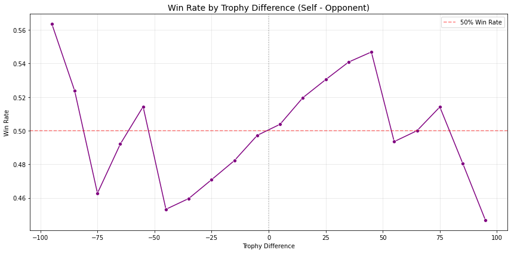

```
Interpretation: Points above 50% line indicate a trophy advantage increases win probability.
```

```python
# Win Rate by Trophy Difference
# Transform: Winner perspective (diff, result=1) + Loser perspective (-diff, result=0)
trophy_diff_vals = df['winner.trophies'] - df['loser.trophies']

win_df = pd.DataFrame({'diff': trophy_diff_vals, 'result': 1})
loss_df = pd.DataFrame({'diff': -trophy_diff_vals, 'result': 0})
combined_df = pd.concat([win_df, loss_df], ignore_index=True)

# Bin the differences
combined_df['diff_bin'] = pd.cut(combined_df['diff'], bins=range(-200, 205, 10))
win_rate_df = combined_df.groupby('diff_bin', observed=True)['result'].agg(['mean', 'count']).reset_index()
win_rate_df['diff_mid'] = win_rate_df['diff_bin'].apply(lambda x: x.mid)
win_rate_df = win_rate_df[win_rate_df['count'] > 100]  # Filter low-count bins

plt.figure(figsize=(12, 6))
sns.lineplot(data=win_rate_df, x='diff_mid', y='mean', marker='o', color='purple')
plt.axhline(0.5, color='red', linestyle='--', alpha=0.5, label='50% Win Rate')
plt.axvline(0, color='gray', linestyle=':', alpha=0.5)
plt.title('Win Rate by Trophy Difference (Self - Opponent)', fontsize=14)
plt.xlabel('Trophy Difference')
plt.ylabel('Win Rate')
plt.legend()
plt.grid(True, alpha=0.3)
plt.tight_layout()
plt.show()

print(f"Interpretation: Points above 50% line indicate a trophy advantage increases win probability.")
```

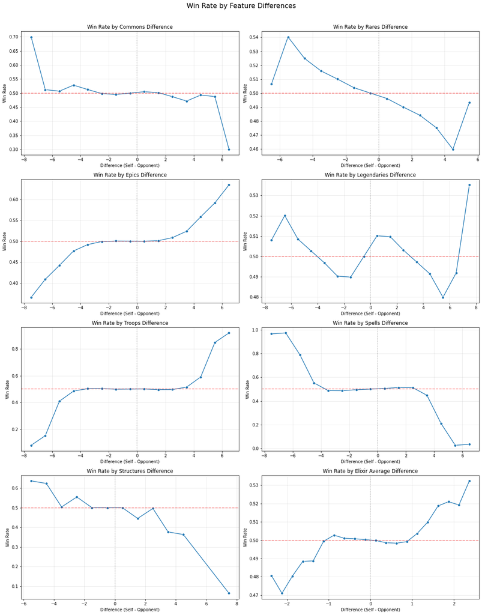

```
Interpretation: Steeper slopes indicate stronger predictive power for that feature.
```

```python
# Win Rate by All Feature Differences (4x2 Grid)
diff_features = ["commons", "rares", "epics", "legendaries", "troops", "spells", "structures", "elixir.average"]

# Define bin settings for different feature types
bin_settings = {
    "troops": range(-8, 9),
    "spells": range(-8, 9),
    "structures": range(-8, 9),
    "commons": range(-8, 9),
    "rares": range(-8, 9),
    "epics": range(-8, 9),
    "legendaries": range(-8, 9),
    "elixir.average": np.linspace(-2.5, 2.5, 21)  # 0.25 steps
}

fig, axes = plt.subplots(4, 2, figsize=(16, 20))
axes = axes.flatten()

for i, feature in enumerate(diff_features):
    # Calculate difference
    diff_vals = df[f'winner.{feature}'] - df[f'loser.{feature}']

    # Winner perspective: diff = val, result = 1
    # Loser perspective: diff = -val, result = 0
    win_vals = diff_vals
    loss_vals = -diff_vals

    combined_diff = pd.concat([win_vals, loss_vals], ignore_index=True)
    combined_result = pd.concat([pd.Series([1]*len(win_vals)), pd.Series([0]*len(loss_vals))], ignore_index=True)

    temp_df = pd.DataFrame({'diff': combined_diff, 'result': combined_result})

    # Determine bins
    bins = bin_settings.get(feature, 20)
    temp_df['diff_bin'] = pd.cut(temp_df['diff'], bins=bins)

    # Calculate win rate
    win_rate_agg = temp_df.groupby('diff_bin', observed=True)['result'].agg(['mean', 'count']).reset_index()
    win_rate_agg['diff_mid'] = win_rate_agg['diff_bin'].apply(lambda x: x.mid)

    # Filter out bins with very few samples
    win_rate_agg = win_rate_agg[win_rate_agg['count'] > 100]

    # Plot
    ax = axes[i]
    sns.lineplot(data=win_rate_agg, x='diff_mid', y='mean', marker='o', ax=ax)
    ax.set_title(f'Win Rate by {feature.replace(".", " ").title()} Difference', fontsize=12)
    ax.set_xlabel('Difference (Self - Opponent)')
    ax.set_ylabel('Win Rate')
    ax.axhline(0.5, color='red', linestyle='--', alpha=0.5)
    ax.axvline(0, color='gray', linestyle=':', alpha=0.5)
    ax.grid(True, alpha=0.3)

plt.suptitle('Win Rate by Feature Differences', fontsize=16, y=1.01)
plt.tight_layout()
plt.show()

print("Interpretation: Steeper slopes indicate stronger predictive power for that feature.")
```

## Feature Importance: Correlation with Win Result

We create a symmetrical dataset where each match contributes two rows (winner perspective with result=1, loser perspective with result=0). The correlation of each feature difference with the result directly measures its predictive importance.

```python
# Build difference DataFrame
df_diff = pd.DataFrame()
df_diff['trophies'] = df['winner.trophies'] - df['loser.trophies']
df_diff['commons'] = df['winner.commons'] - df['loser.commons']
df_diff['rares'] = df['winner.rares'] - df['loser.rares']
df_diff['epics'] = df['winner.epics'] - df['loser.epics']
df_diff['legendaries'] = df['winner.legendaries'] - df['loser.legendaries']
df_diff['troops'] = df['winner.troops'] - df['loser.troops']
df_diff['spells'] = df['winner.spells'] - df['loser.spells']
df_diff['structures'] = df['winner.structures'] - df['loser.structures']
df_diff['elixir_avg'] = df['winner.elixir.average'] - df['loser.elixir.average']

# Create symmetrical dataset: winner perspective (result=1) + loser perspective (result=0)
full_data = pd.concat([
    df_diff.assign(result=1),
    (-df_diff).assign(result=0)
], ignore_index=True)

# Calculate correlations with result
correlations = full_data.corr()[['result']].drop('result')
correlations = correlations.sort_values(by='result', ascending=False)

# Display as formatted table
print("=" * 50)
print("FEATURE IMPORTANCE: Correlation with Win Result")
print("=" * 50)
print(f"{'Feature':<20} | {'Correlation':>12}")
print("-" * 50)
for idx, row in correlations.iterrows():
    print(f"{idx:<20} | {row['result']:>12.4f}")
print("-" * 50)
print("\nInterpretation:")
print("  • Positive correlation = Higher value increases win probability")
print("  • Negative correlation = Higher value decreases win probability")
print("  • Magnitude indicates strength of predictive power")
```

```
==================================================
FEATURE IMPORTANCE: Correlation with Win Result
==================================================
Feature              |  Correlation
--------------------------------------------------
trophies             |       0.0393
epics                |       0.0161
legendaries          |       0.0097
spells               |       0.0089
elixir_avg           |       0.0055
troops               |       0.0027
commons              |      -0.0082
structures           |      -0.0175
rares                |      -0.0186
--------------------------------------------------

Interpretation:
  • Positive correlation = Higher value increases win probability
  • Negative correlation = Higher value decreases win probability
  • Magnitude indicates strength of predictive power
```

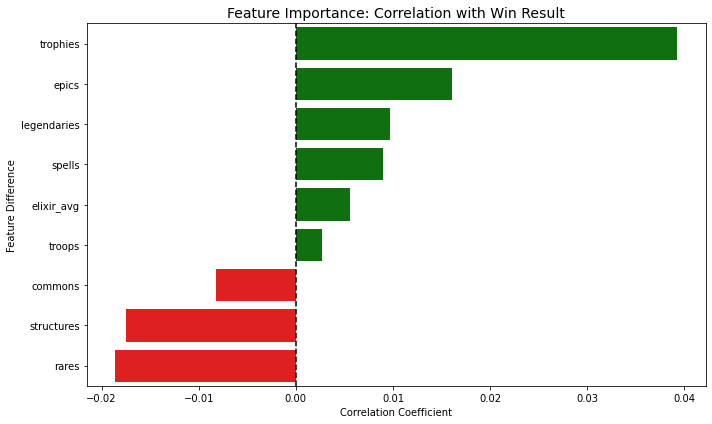

```python
# Visualize feature importance
plt.figure(figsize=(10, 6))
colors = ['green' if x > 0 else 'red' for x in correlations['result']]
sns.barplot(x=correlations['result'], y=correlations.index, palette=colors)
plt.axvline(0, color='black', linestyle='--')
plt.title('Feature Importance: Correlation with Win Result', fontsize=14)
plt.xlabel('Correlation Coefficient')
plt.ylabel('Feature Difference')
plt.tight_layout()
plt.show()
```

## Card-Level Analysis: Per-Card Win Rate Correlation

We parse the card IDs from each deck and calculate how each individual card correlates with winning.

```python
import ast

card_sample_size = 50000
df_card_sample = df.sample(min(card_sample_size, len(df)), random_state=42).copy()

# Function to safely parse the string representation of lists
def safe_parse(x):
    try:
        return ast.literal_eval(x)
    except:
        return []

df_card_sample['winner.cards_list'] = df_card_sample['winner.cards'].apply(safe_parse)
df_card_sample['loser.cards_list'] = df_card_sample['loser.cards'].apply(safe_parse)
deck_data = []

# Process winners (result=1)
for cards in df_card_sample['winner.cards_list']:
    deck_info = {str(card): 1 for card in cards}
    deck_info['result'] = 1
    deck_data.append(deck_info)

# Process losers (result=0)
for cards in df_card_sample['loser.cards_list']:
    deck_info = {str(card): 1 for card in cards}
    deck_info['result'] = 0
    deck_data.append(deck_info)

# Create DataFrame (fillna(0) handles cards not present in a deck)
cards_df = pd.DataFrame(deck_data).fillna(0)
card_correlations = cards_df.corr()['result'].drop('result')
card_correlations = card_correlations.reindex(card_correlations.abs().sort_values(ascending=False).index)
print(f"Analyzed {len(df_card_sample)} matches, {len(card_correlations)} unique cards found.\n")
```

```
Analyzed 50000 matches, 102 unique cards found.
```

```python
import json
cardsid2name = { card["id"]: card["name"] for card in json.load(open("cards.json")) }
# Display card correlations (top 20 highest and lowest)
# print("CARD WIN RATE CORRELATIONS (Sorted by Absolute Value)")
# print(f"{'Card ID':<15} | {'Correlation':>12} | {'Interpretation':<20}")
# print("-" * 55)
# for i, card_id in enumerate(card_correlations.index[:20]):
#     corr = card_correlations[card_id]
#     interpretation = "Favors Winning" if corr > 0 else "Favors Losing"
#     print(f"{card_id:<15} | {corr:>12.4f} | {interpretation:<20}")
# print("-" * 55)

print(f"\nTop 5 cards that correlate with WINNING:")
for card_id in card_correlations.nlargest(5).index:
    print(f"  Card {cardsid2name[int(card_id)]}: {card_correlations[card_id]:+.4f}")

print(f"\nTop 5 cards that correlate with LOSING:")
for card_id in card_correlations.nsmallest(5).index:
    print(f"  Card {cardsid2name[int(card_id)]}: {card_correlations[card_id]:+.4f}")
```

```
Top 5 cards that correlate with WINNING:
  Card The Log: +0.0144
  Card Battle Ram: +0.0118
  Card Hunter: +0.0101
  Card Dark Prince: +0.0098
  Card P.E.K.K.A: +0.0097

Top 5 cards that correlate with LOSING:
  Card Musketeer: -0.0237
  Card Archers: -0.0232
  Card Tombstone: -0.0193
  Card Giant: -0.0162
  Card Elixir Golem: -0.0154
```

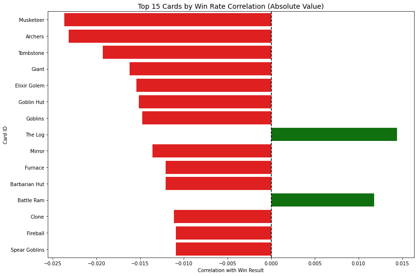

```python
# Visualize top cards by correlation
top_n = 15
top_cards = card_correlations.head(top_n)

plt.figure(figsize=(12, 8))
colors = ['green' if x > 0 else 'red' for x in top_cards.values]
sns.barplot(x=top_cards.values, y=[cardsid2name[int(card_id)] for card_id in top_cards.index], palette=colors)
plt.axvline(0, color='black', linestyle='--')
plt.title(f'Top {top_n} Cards by Win Rate Correlation (Absolute Value)', fontsize=14)
plt.xlabel('Correlation with Win Result')
plt.ylabel('Card ID')
plt.tight_layout()
plt.show()
```

**Observations:**

- Cards with positive correlations tend to appear more frequently in winning decks
- Cards with negative correlations may be underperforming in the current meta
- The magnitude indicates how strongly a card influences win probability

# Baseline(Logistic regression) model

```python
import numpy as np # linear algebra
import pandas as pd # data processing, CSV file I/O (e.g. pd.read_csv)
import json
from sklearn.preprocessing import OneHotEncoder
from sklearn.linear_model import LogisticRegression
from sklearn.model_selection import train_test_split
from sklearn.metrics import accuracy_score
from sklearn.preprocessing import OrdinalEncoder
import gzip
import matplotlib.pyplot as plt
from sklearn.metrics import roc_curve, auc, RocCurveDisplay
```

```python
df = pd.read_csv('cse158-assignment2-master.csv')
df_small = df.sample(10000)
```

```python
df_small.head()
```

```python
## Helper functions to generate new column names for rows separately for the
## winner and loser for each match

def generate_winner_row(row):
    new_col_dict = {}
    for col in df_small.drop(['winner.cards', 'loser.cards'], axis=1).columns:
        if 'winner' in col:
            new_col_dict['p_' + col.replace('winner.', '')] = row[col]
        if 'loser' in col:
            new_col_dict['opp_' + col.replace('loser.', '')] = row[col]
    new_col_dict['result'] = 1
    return new_col_dict

def generate_loser_row(row):
    new_col_dict = {}
    for col in df_small.drop(['winner.cards', 'loser.cards'], axis=1).columns:
        if 'winner' in col:
            new_col_dict['opp_' + col.replace('winner.', '')] = row[col]
        if 'loser' in col:
            new_col_dict['p_' + col.replace('loser.', '')] = row[col]
    new_col_dict['result'] = 0
    return new_col_dict
```

```python
## Creating new dataframe that has separate rows for
## the winner and loser of each matchup
rows = []

for _, r in df_small.iterrows():
    # winner row
    rows.append(generate_winner_row(r))
    # loser row
    rows.append(generate_loser_row(r))

df2 = pd.DataFrame(rows)
```

```python
## Fitting logistic regression

X = df2.drop(columns=["result"])
y = df2["result"]

X_train, X_test, y_train, y_test = train_test_split(X, y, test_size=0.2, random_state=42)
model = LogisticRegression(solver='liblinear', random_state=42) # 'liblinear' is a good default solver
model.fit(X_train, y_train)
y_pred = model.predict(X_test)
accuracy = accuracy_score(y_test, y_pred)
print(f"Model Accuracy: {accuracy}")
```

```python
# Plotting ROC Curve

### Generating predicted values
y_pred_proba = model.predict_proba(X_test)[:, 1] # Probability of belonging to class 1

fpr, tpr, thresholds = roc_curve(y_test, y_pred_proba)

### Calculate the Area Under the Curve (AUC)
roc_auc = auc(fpr, tpr)

### Plot the ROC curve
plt.figure(figsize=(8, 6))
plt.plot(fpr, tpr, color='darkorange', lw=2, label=f'ROC curve (AUC = {roc_auc:.2f})')
plt.plot([0, 1], [0, 1], color='navy', lw=2, linestyle='--', label='Random Classifier')
plt.xlim([0.0, 1.0])
plt.ylim([0.0, 1.05])
plt.xlabel('False Positive Rate')
plt.ylabel('True Positive Rate')
plt.title('Receiver Operating Characteristic (ROC) Curve')
plt.legend(loc='lower right')
plt.grid(True)
plt.show()
```

# Transformer model

```python
import pandas as pd
import numpy as np
import matplotlib.pyplot as plt
import seaborn as sns
from sklearn.model_selection import train_test_split
from sklearn.preprocessing import StandardScaler
from sklearn.metrics import accuracy_score, classification_report, confusion_matrix

import torch
import torch.nn as nn
import torch.optim as optim

np.random.seed(42)
torch.cuda.manual_seed_all(42)
pd.set_option('display.max_columns', None)
sns.set(style="whitegrid")
```

## Loading Data

```python
from google.colab import drive
drive.mount('/content/drive/')
dataRoot = "drive/MyDrive/'CSE158 258_assignment2'"
```

```python
%%bash
if [ ! -f "cse158-assignment2-master.csv" ] ; then
  cp drive/MyDrive/'CSE158 258_assignment2/cse158-assignment2-master.csv.gz' .
  gzip -d cse158-assignment2-master.csv.gz
fi
```

```python
FILE_PATH = 'cse158-assignment2-master.csv'
SAMPLE_SIZE = 10_000_000
df = pd.read_csv(FILE_PATH,
                #  nrows=SAMPLE_SIZE,
                 low_memory=True,
                 dtype={'loser.trophies': pd.Int16Dtype(),
                        'winner.trophies': pd.Int16Dtype(),
                        'winner.troops': pd.Int16Dtype(),
                        'winner.structures': pd.Int16Dtype(),
                        'winner.spells': pd.Int16Dtype(),
                        'loser.troops': pd.Int16Dtype(),
                        'loser.structures': pd.Int16Dtype(),
                        'loser.spells': pd.Int16Dtype(),
                        }
                 )

if 'Unnamed: 0' in df.columns:
    df.drop('Unnamed: 0', axis=1, inplace=True)
print(f"Dataset shape: {df.shape}")
```

```
Dataset shape: (17410767, 22)
```

## Feature Engineering

```python
df = df.copy()
rarities = ['commons', 'rares', 'epics', 'legendaries']
for rarity in rarities:
    feature_name = f"{rarity}_diff"
    df[f'winner.{feature_name}'] = df[f'winner.{rarity}'] - df[f'loser.{rarity}']
    df[f'loser.{feature_name}'] = df[f'loser.{rarity}'] - df[f'winner.{rarity}']

# trophydiff
df['winner.trophies_diff'] = df['winner.trophies'] - df['loser.trophies']
df['loser.trophies_diff'] = df['loser.trophies'] - df['winner.trophies']
```

## Data reformat to add winner/loser label

```python
from sklearn.preprocessing import MultiLabelBinarizer
import json
import gc

def restructure_data(df):
    # parse cards obj to array
    winner_decks = df['winner.cards'].apply(json.loads).tolist()
    loser_decks = df['loser.cards'].apply(json.loads).tolist()

    # OHE cards
    mlb = MultiLabelBinarizer()
    mlb.fit(winner_decks + loser_decks)

    # Transform creates int32/int64 arrays. ~2GB each.
    winner_cards_encoded = mlb.transform(winner_decks)
    loser_cards_encoded = mlb.transform(loser_decks)

    # save mem
    del winner_decks, loser_decks
    gc.collect()

    card_feat_names = [f"card_{c}" for c in mlb.classes_]
    scalar_feature_names = [
        'trophies', 'troops', 'structures', 'spells',
        'commons', 'rares', 'epics', 'legendaries',
        'elixir.average',
        'isinclan',
        'commons_diff', 'rares_diff', 'epics_diff', 'legendaries_diff',
        'trophies_diff'
    ]

    available_scalars = [f for f in scalar_feature_names if f'winner.{f}' in df.columns]
    print(f"Using {len(available_scalars)} scalar features per player")

    n_samples = len(df)
    n_scalars = len(available_scalars)
    n_cards = len(card_feat_names)
    total_features = n_scalars + n_cards


    # cut down mem use f16
    player1_data = np.zeros((n_samples, total_features), dtype=np.float16)
    player2_data = np.zeros((n_samples, total_features), dtype=np.float16)

    # randomly assign p1, p2
    # True: P1=Winner, P2=Loser | False: P1=Loser, P2=Winner
    swap_mask = np.random.rand(n_samples) > 0.5
    labels = swap_mask.astype(int)



    for i, feature in enumerate(available_scalars):
        w_vals = df[f'winner.{feature}'].values
        l_vals = df[f'loser.{feature}'].values

        # np.where copies data directly to destination
        player1_data[:, i] = np.where(swap_mask, w_vals, l_vals)
        player2_data[:, i] = np.where(swap_mask, l_vals, w_vals)


    c_start = n_scalars
    player1_data[swap_mask, c_start:] = winner_cards_encoded[swap_mask]
    player1_data[~swap_mask, c_start:] = loser_cards_encoded[~swap_mask]

    player2_data[swap_mask, c_start:] = loser_cards_encoded[swap_mask]
    player2_data[~swap_mask, c_start:] = winner_cards_encoded[~swap_mask]

    # save mem
    del winner_cards_encoded, loser_cards_encoded
    gc.collect()

    return player1_data, player2_data, labels

player1_data, player2_data, labels = restructure_data(df)
print(f"Player data shape: {player1_data.shape}")
```

```
Using 15 scalar features per player
Player data shape: (17410767, 117)
```

## recombine for model input

```python
n_samples = player1_data.shape[0]
n_features = player1_data.shape[1]
X = np.stack([player1_data, player2_data], axis=1)
y = labels

print(f"X shape: {X.shape} (samples, sequence_length=2, features)")
print(f"y shape: {y.shape}")
```

```
X shape: (17410767, 2, 117) (samples, sequence_length=2, features)
y shape: (17410767,)
```

## Train/Test Split and Feature Scaling

```python
import gc
try:
    del player1_data, player2_data
except NameError:
    pass
gc.collect()

# Split data
print(f"Splitting data (Input shape: {X.shape})...")
X_train, X_test, y_train, y_test = train_test_split(
    X, y, test_size=0.2, random_state=42, stratify=y
)

# free mem
print("Releasing original dataset memory...")
del X, y
gc.collect()

print(f"Train set: {X_train.shape[0]:,} samples")
print(f"Test set: {X_test.shape[0]:,} samples")

# Feature Scaling
# We should ONLY scale the continuous scalar features, not the one-hot card features.
N_SCALARS = 15


# flattened views for the scalar portion
X_train_scalars_view = X_train[:, :, :N_SCALARS]
X_test_scalars_view = X_test[:, :, :N_SCALARS]

scaler = StandardScaler()

# We must reshape to (N_samples * 2, N_features) for the scaler
# Then reshape back and assign to the view
X_train_scalars_view[:] = scaler.fit_transform(
    X_train_scalars_view.reshape(-1, N_SCALARS)
).reshape(X_train.shape[0], 2, N_SCALARS)

X_test_scalars_view[:] = scaler.transform(
    X_test_scalars_view.reshape(-1, N_SCALARS)
).reshape(X_test.shape[0], 2, N_SCALARS)

X_train_scaled = X_train
X_test_scaled = X_test

print(f"Scaled train shape: {X_train_scaled.shape}")
```

```
Splitting data (Input shape: (17410767, 2, 117))...
Releasing original dataset memory...
Train set: 13,928,613 samples
Test set: 3,482,154 samples
Scaled train shape: (13928613, 2, 117)
```

## Transformer

```python
import torch
import torch.nn as nn
import torch.optim as optim

device = torch.device('cuda' if torch.cuda.is_available() else 'cpu')
print(f"Using device: {device}")

class ClashRoyaleTransformer(nn.Module):
    def __init__(self, input_size, d_model=256, nhead=16, num_layers=3, dim_feedforward=1024, dropout=0.1):
        super(ClashRoyaleTransformer, self).__init__()

        self.d_model = d_model
        # Embedding layer to project features to d_model size
        self.embedding = nn.Linear(input_size, d_model)
        # Transformer Encoder
        encoder_layer = nn.TransformerEncoderLayer(
            d_model=d_model,
            nhead=nhead,
            dim_feedforward=dim_feedforward,
            dropout=dropout,
            batch_first=True
        )
        self.transformer_encoder = nn.TransformerEncoder(encoder_layer, num_layers=num_layers)

        # Final classification head
        self.fc = nn.Sequential(
            nn.Linear(d_model * 2, 128), # Flatten the sequence: 2 * d_model
            nn.ReLU(),
            nn.Dropout(dropout),
            nn.Linear(128, 64),
            nn.ReLU(),
            nn.Linear(64, 1),
            nn.Sigmoid()
        )

    def forward(self, x):
        # x shape: (batch, seq_len, features)
        batch_size = x.size(0)
        x = self.embedding(x)
        x = self.transformer_encoder(x)
        # Flatten output: (batch, seq_len, d_model) -> (batch, seq_len * d_model)
        x = x.reshape(batch_size, -1)
        output = self.fc(x)
        return output

# Prepare data as PyTorch tensors
X_train_tensor = torch.FloatTensor(X_train_scaled).to(device)
y_train_tensor = torch.FloatTensor(y_train).reshape(-1, 1).to(device)
X_test_tensor = torch.FloatTensor(X_test_scaled).to(device)
y_test_tensor = torch.FloatTensor(y_test).reshape(-1, 1).to(device)

# Create model
input_features = X_train_scaled.shape[2]
model = ClashRoyaleTransformer(input_size=input_features).to(device)

class HistoryObject:
    def __init__(self):
        self.history = {}
```

```
Using device: cuda
```

## Training

```python
from torch.utils.data import TensorDataset, DataLoader
import torch.optim.lr_scheduler as lr_scheduler
import time
from tqdm.auto import tqdm

EPOCHS = 40
BATCH_SIZE = 2048 // 2

# dataloaders
train_dataset = TensorDataset(X_train_tensor, y_train_tensor)
val_dataset = TensorDataset(X_test_tensor, y_test_tensor) # test as validation

train_loader = DataLoader(train_dataset, batch_size=BATCH_SIZE, shuffle=True)
val_loader = DataLoader(val_dataset, batch_size=BATCH_SIZE, shuffle=False)

criterion = nn.BCELoss()
optimizer = optim.Adam(model.parameters(), lr=0.001)
scheduler = lr_scheduler.ReduceLROnPlateau(
    optimizer, mode='min', factor=0.2, patience=3, min_lr=1e-6
)

train_losses, train_accs, val_losses, val_accs = [], [], [], []
best_val_loss = float('inf')
patience = 8
patience_counter = 0

for epoch in range(EPOCHS):
    start_time = time.time()

    # training epoch
    model.train()
    running_loss = 0.0
    correct = 0
    total = 0

    with tqdm(total=len(train_dataset), desc=f"Epoch {epoch+1}/{EPOCHS}", unit="sample") as train_pbar:
        for inputs, targets in train_loader:
            optimizer.zero_grad()
            outputs = model(inputs)
            loss = criterion(outputs, targets)
            loss.backward()
            optimizer.step()

            batch_size = inputs.size(0)
            running_loss += loss.item() * batch_size
            predicted = (outputs > 0.5).float()
            correct += (predicted == targets).sum().item()
            total += batch_size

            train_pbar.update(batch_size)
            train_pbar.set_postfix({'loss': f"{loss.item():.4f}"})

    epoch_loss = running_loss / total
    epoch_acc = correct / total
    train_losses.append(epoch_loss)
    train_accs.append(epoch_acc)

    # validation
    model.eval()
    val_running_loss = 0.0
    val_correct = 0
    val_total = 0

    with torch.no_grad():
        for inputs, targets in val_loader:
            outputs = model(inputs)
            loss = criterion(outputs, targets)

            val_running_loss += loss.item() * inputs.size(0)
            predicted = (outputs > 0.5).float()
            val_correct += (predicted == targets).sum().item()
            val_total += targets.size(0)

    epoch_val_loss = val_running_loss / val_total
    epoch_val_acc = val_correct / val_total

    val_losses.append(epoch_val_loss)
    val_accs.append(epoch_val_acc)

    scheduler.step(epoch_val_loss)
    current_lr = optimizer.param_groups[0]['lr']

    end_time = time.time()
    epoch_duration = end_time - start_time

    print(f"Epoch {epoch+1}/{EPOCHS} - "
          f"loss: {epoch_loss:.4f} - accuracy: {epoch_acc:.4f} - "
          f"val_loss: {epoch_val_loss:.4f} - val_accuracy: {epoch_val_acc:.4f} - "
          f"lr: {current_lr:.6f} - time: {epoch_duration:.2f}s")

    # early stopping
    if epoch_val_loss < best_val_loss:
        best_val_loss = epoch_val_loss
        torch.save(model.state_dict(), 'clash_royale_transformer_best.pth')
        patience_counter = 0
    else:
        patience_counter += 1
        if patience_counter >= patience:
            print(f"Early stopping triggered at epoch {epoch+1}")
            break

history = HistoryObject()
history.history['loss'] = train_losses
history.history['accuracy'] = train_accs
history.history['val_loss'] = val_losses
history.history['val_accuracy'] = val_accs
```

## Training History Visualization

```python
fig, axes = plt.subplots(1, 2, figsize=(12, 5))

# Loss
axes[0].plot(history.history['loss'], label='Train Loss', marker=None)
axes[0].plot(history.history['val_loss'], label='Val Loss', marker=None)
axes[0].set_title('Model Loss Over Epochs', fontsize=14, fontweight='bold')
axes[0].set_xlabel('Epoch')
axes[0].set_ylabel('Loss')
axes[0].legend()
axes[0].grid(True, alpha=0.3)

# Accuracy
axes[1].plot(history.history['accuracy'], label='Train Accuracy', marker=None)
axes[1].plot(history.history['val_accuracy'], label='Val Accuracy', marker=None)
axes[1].set_title('Model Accuracy Over Epochs', fontsize=14, fontweight='bold')
axes[1].set_xlabel('Epoch')
axes[1].set_ylabel('Accuracy')
axes[1].legend()
axes[1].grid(True, alpha=0.3)

plt.tight_layout()
plt.show()
```

## Model Evaluation on Test Set

```python
print("EVALUATING MODEL ON TEST SET")
model.eval()
test_dataset = TensorDataset(X_test_tensor, y_test_tensor)
test_loader = DataLoader(test_dataset, batch_size=BATCH_SIZE, shuffle=False)

all_preds = []
total_test_loss = 0.0
num_batches = 0
criterion = nn.BCELoss()

print(f"Evaluating on {len(test_dataset):,} samples in batches of {BATCH_SIZE}...")

with torch.no_grad():
    for inputs, targets in tqdm(test_loader, desc="Testing"):
        # Forward pass
        outputs = model(inputs)

        # Calculate loss for this batch
        loss = criterion(outputs, targets)
        total_test_loss += loss.item()
        num_batches += 1

        # Store predictions (move to CPU to save GPU memory)
        all_preds.append(outputs.cpu().numpy())

y_pred_prob = np.concatenate(all_preds).flatten()
test_loss = total_test_loss / num_batches
y_pred = (y_pred_prob > 0.5).astype(int)
test_accuracy = accuracy_score(y_test, y_pred)

print(f"\nTest Results:")
print(f"  - Loss: {test_loss:.4f}")
print(f"  - Accuracy: {test_accuracy:.4f} ({test_accuracy*100:.2f}%)")

print("\nCLASSIFICATION REPORT")
print(classification_report(y_test, y_pred, target_names=['Player2 Wins', 'Player1 Wins']))
```

```python
torch.save(model.state_dict(), 'clash_royale_transformer_final.pth')
```

# MLP network model

```python
# IMPORTS
import gzip
import torch
import torch.nn as nn
import torch.optim as optim
import pandas as pd
import numpy as np
from sklearn.model_selection import train_test_split
from sklearn.metrics import accuracy_score
```

## Data Processing

```python
df = []

df = pd.read_csv("cse158-assignment2-master.csv.gz", compression="gzip", nrows=500000)
```

```python
stat_columns = [
        "trophies", "isinclan", "troops", "structures", "spells",
        "commons", "rares", "epics", "legendaries", "elixir.average"
]
```

```python
# A is winner, B is loser
rows_A_winner = {}
for stat in stat_columns:
    rows_A_winner[f"A.{stat}"] = df[f"winner.{stat}"]
    rows_A_winner[f"B.{stat}"] = df[f"loser.{stat}"]
y_A_winner = pd.Series(np.ones(len(df)), name="label")   # A won = 1

df_A = pd.DataFrame(rows_A_winner)
df_A["label"] = y_A_winner
```

```python
# B is winner, A is loser
rows_B_winner = {}
for stat in stat_columns:
    rows_B_winner[f"A.{stat}"] = df[f"winner.{stat}"]
    rows_B_winner[f"B.{stat}"] = df[f"loser.{stat}"]
y_B_winner = pd.Series(np.zeros(len(df)), name="label")   # A lost = 0

df_B = pd.DataFrame(rows_B_winner)
df_B["label"] = y_B_winner
```

```python
df_pairs = pd.concat([df_A, df_B], ignore_index=True)
```

## Building Feature Vector

We used difference features, like delta_trophies (A.trophies - B.trophies), to improve prediction accuracy for competitive game matchups.

```python
diff_features = {}

for stat in stat_columns:
    diff_features[f"delta_{stat}"] = df_pairs[f"A.{stat}"].astype(np.float32) - df_pairs[f"B.{stat}"].astype(np.float32)

df_diff = pd.DataFrame(diff_features)
```

```python
# Feature Matrix

X = df_diff
y = df_pairs["label"]
```

## Train Val/Test Split

```python
X_train, X_test, y_train, y_test = train_test_split(
    X, y, test_size=0.20, random_state=42
)
```

## Building Neural Network

We used multiple hidden layers in our implementation.

```python
class ClashRoyaleNetwork(nn.Module):
    def __init__(self, input_dim):
        super().__init__()
        self.net = nn.Sequential(
            nn.Linear(input_dim, 64),
            nn.ReLU(),
            nn.BatchNorm1d(64),
            nn.Dropout(0.2),

            nn.Linear(64, 32),
            nn.ReLU(),
            nn.BatchNorm1d(32),
            nn.Dropout(0.2),

            nn.Linear(32, 1),
            nn.Sigmoid()
        )

    def forward(self, x):
        return self.net(x)
```

```python
model = ClashRoyaleNetwork(input_dim=X_train.shape[1])
criterion = nn.BCELoss()
optimizer = optim.Adam(model.parameters(), lr=0.005)
```

```python
X_train_t = torch.tensor(X_train.values, dtype=torch.float32)
y_train_t = torch.tensor(y_train.values, dtype=torch.float32)

for epoch in range(25):
    model.train()
    optimizer.zero_grad()

    preds = model(X_train_t).squeeze()
    loss = criterion(preds, y_train_t)

    loss.backward()
    optimizer.step()

    if epoch % 5 == 0:
        print(f"epoch {epoch} | loss = {loss.item():.4f}")
```

## Evaluation

```python
model.eval()
X_test_t = torch.tensor(X_test.values, dtype=torch.float32)

with torch.no_grad():
    predictions = model(X_test_t).squeeze()
    predictions = (predictions > 0.5).numpy()

accuracy = accuracy_score(y_test, predictions)
print("Test accuracy:", accuracy)
```